```r
duomenys<-read.csv("https://raw.githubusercontent.com/1vbutkus/Econometrics1/master/task15/data.csv", header = TRUE)
```

Kaip atrodo musu duomenys:

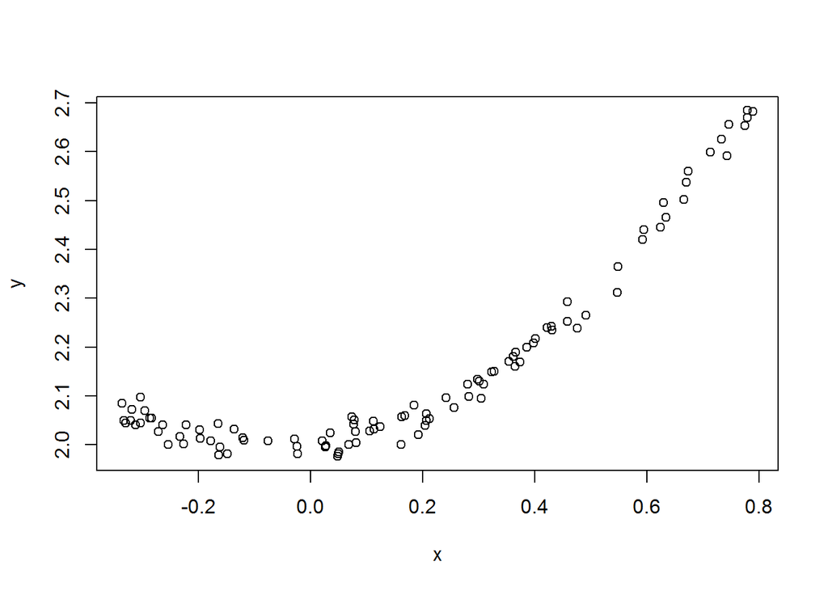

```r
x<-duomenys$x
y<-duomenys$y
plot(x,y)
```

Sudarome modeli (antro laipsnio polinomas)

```r
modelis<-lm(y~x+I(x^2))
summary(modelis)
```

```
##
## Call:
## lm(formula = y ~ x + I(x^2))
##
## Residuals:
##       Min        1Q    Median        3Q       Max
## -0.046193 -0.013816  0.004572  0.013568  0.043686
##
## Coefficients:
##             Estimate Std. Error t value Pr(>|t|)
## (Intercept) 2.000764   0.002676  747.66   <2e-16 ***
## x           0.120730   0.009876   12.22   <2e-16 ***
## I(x^2)      0.972004   0.019229   50.55   <2e-16 ***
## ---
## Signif. codes:  0 '***' 0.001 '**' 0.01 '*' 0.05 '.' 0.1 ' ' 1
##
## Residual standard error: 0.02047 on 97 degrees of freedom
## Multiple R-squared:  0.9897, Adjusted R-squared:  0.9895
## F-statistic:  4652 on 2 and 97 DF,  p-value: < 2.2e-16
```

PAAIšKINIMAI

Call:

Rodo, kaip sudaryta formulė.

Residuals (liekamosios paklaidos) yra skirtumas tarp stebetu reikšmių ir reikšmių, kurias nuspėjo regresijos modelis. Jei modelis geras, mūsų residuals duomenys turėtų būti simetriški (taip ir yra), o Median arti nulio (Mūsų modelyje ji arti nulio)

Coefficients:

Std. Error - sklaidos matas, kuris nusako sklaidą apie mūsų apskaičiuotus koeficientus.

t-value

Skirtos apskaičiuoti pasikliovimo lygmenį bei p reikšmes.

p-value

Tikimybė, jog kintamieji yra nesusiję vienas su kitu. Šios reiksmės mums reikalingos kuo mažesnės - mūsų atveju jos yra labai mažos.

Residual standard error-Paklaidų standartinis nuokrypis yra vidutinis dydis, kuriuo mūsų priklausomas kintamasis skirsis nuo tikrosios regresijos tiesės. Paklaidų standartinis nuokrypis buvo apskaičiuotas su 97 laisves laipsniais.

Multiple R-squared: 0.9897, Adjusted R-squared: 0.9895

Tai matas, skirtas įvertinti modelio tinkamumą stebėjimams. Kuo didesnis skaičius - tuo modelis geresnis. Vienetas atitinka tobulą modelį, o mažiausia reikšmė - 0. Interpretacija: šiuo atveju apytiksliai 99 procentai y yra paaiškinami pagal nepriklausomą kintamąjį. (R-squared indikuoja aukstą koreliaciją, bet nebūtinai aukštą priežastingumą).

F-statistic: 4652 on 2 and 97 DF, p-value: < 2.2e-16

Indikatorius , nusakantis ryšį tarp priklausomo ir nepriklausomo kintamujų. Kuo toliau F-statistic yra nuo 1 , tuo geriau.

Modelio prognozės taškuose (0, 0.3, 0.5).

```r
prognozes<-predict(modelis,newdata=data.frame(x=c(0,0.3,0.5)))
prognozes
```

```
##        1        2        3
## 2.000764 2.124464 2.304130
```

Kintamųjų sklaidos diagrama:

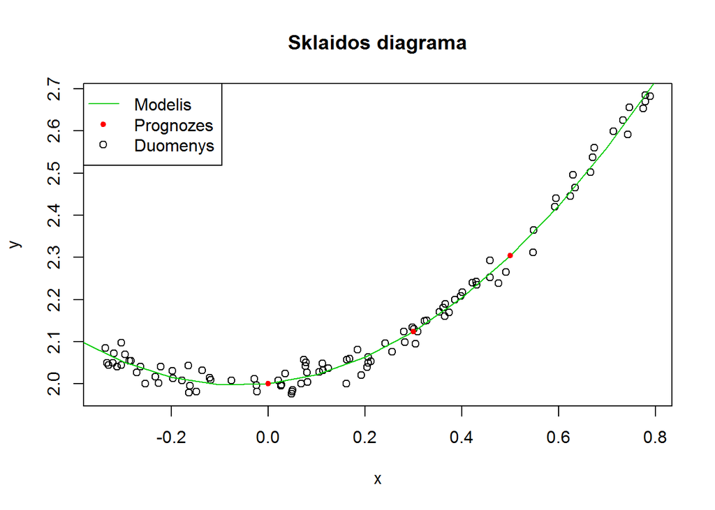

```r
plot(x, y, xlab="x", ylab="y",main="Sklaidos diagrama",pch=1)
xvalues<-seq(-0.5,1,0.1)
prognozesmodelio<-predict(modelis, list(x=xvalues, x2=xvalues^2))
lines(xvalues, prognozesmodelio      , col=3,      lwd=1)
points(c(0,0.3,0.5), prognozes, col=2, pch=20)
legend("topleft", legend = c("Modelis","Prognozes", "Duomenys" ), col = c(3,2,1), lty = c(1,NA,NA), pch=c(NA, 20, 1) )
```

Ref. http://www.theanalysisfactor.com/r-tutorial-4/ http://blog.yhat.com/posts/r-lm-summary.html https://www.r-bloggers.com/polynomial-regression-techniques/